# Food Availability in West Africa

Bryce Leary, Milika Robbins, Zeinabou Saidou Baraze, Carine Ayidehou

1/11/2020

# Abstract

# Introduction

According to the World Food Summit of 1996, food security is defined as “…when all people, at all times, have physical, social and economic access to sufficient, safe and nutritious food to meet dietary needs for a productive and healthy life” (UN, 2014). Food insecurity is therefore the absence of these conditions. Over decades now, the global food security has been a major challenge for global communities to manage. About 821 million people across the world suffered from hunger in 2018 according to the United Nations. With the world population fast growing, we would need to provide food for an estimate of 9 Billion people by the year 2050 (Breene, 2016). This means that the number of people suffering from hunger would further increase over years; as a result, we should place more urgency on resolving this issue.

The major contributing factors to the inability to meet food security range from a fast population growth, climate change, water scarcity, a decrease in the number of farmers, high cost of farming (Breene, 2016) and political instability in many countries (Maxwell, 2012). Policymakers and global leaders are committed to ending hunger and have codified this effort through the Millennium Challenge Goals, the Sustainable Development Goals, and the UN’s Zero Hunger Challenge.

In order to meet these goals, policy makers have invested into initiatives to fund the agricultural sector and engaged in partnerships with farmers and major stakeholders to bring forth comprehensive solutions to improve the global food production. This analysis will focus on the availability of good in the region of West Africa. We seek to understand how capital flows in the agricultural sector influence the availability of food in West African countries.

# Data Collection Method

The second dataset is the Foreign Direct Investment (FDI). which is measured in terms of 2016 US Millions of dollars. This dataset was last updated on November 11, 2019 and covers the total FDI inflow and outflows to and from developing countries in the West Africa region. This dataset was collected by the United Nations Conference on Trade and Development (UNCTAD), The International Trade Centre (INTRACEN), the Organization for Economic Co-operation and Development (OECD) and the International Monetary Fund (IMF) Balance of Payments Manual. Both the DevAid and FDI datasets are from the FAO data group of Development Flows to Agriculture.

The third dataset is the Average Dietary Energy Supply Adequacy (ADESA) from the FAO’s Suite of Food Security Indicators which was last updated on October 11, 2019. It is represented in a three-year average format and is indicated as a percentage (FAO 2019). The dietary energy supply is determined by each country’s average supply of calories for food consumption of the population.

The fourth and fifth datasets are presented as imports and exports of crops and livestock products. Both exports and imports include the total of aggregated agricultural products by country on an annual basis. These datasets were last updated on October 9, 2019. This agricultural trade data was collected corresponding to the Standard International Merchandise Trade Statistics Methodology; the main providers of this data are UNSD and Eurostat, but other providers are involved if needed for non-reporting countries or missing cells (FAO 2019).

The sixth and last data set is the Depth of Food Deficit (Depth) and originates from the World Bank Data Development Indicators, which were sourced from the FAO’s Food Security Statistics and last updated on December 4, 2019. The key indicator in this dataset is represented in kilocalories per person per day, based on the number of calories needed per day to lift the undernourished population from this category when everything else remains the same.

[output not shown]

# Linear Regression Analysis

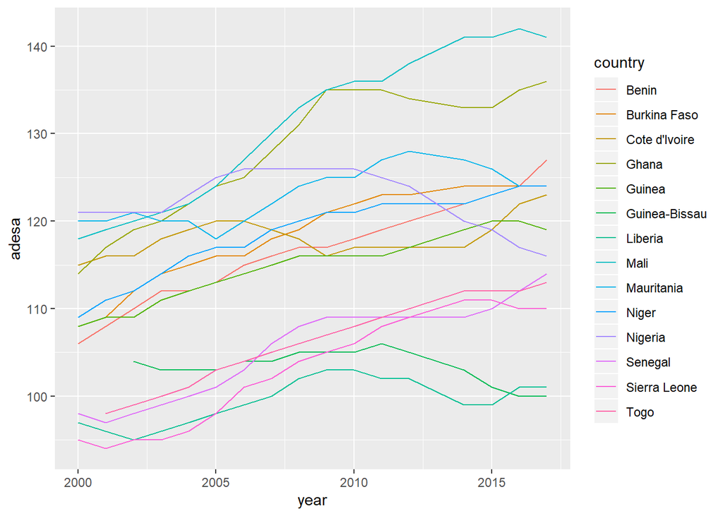

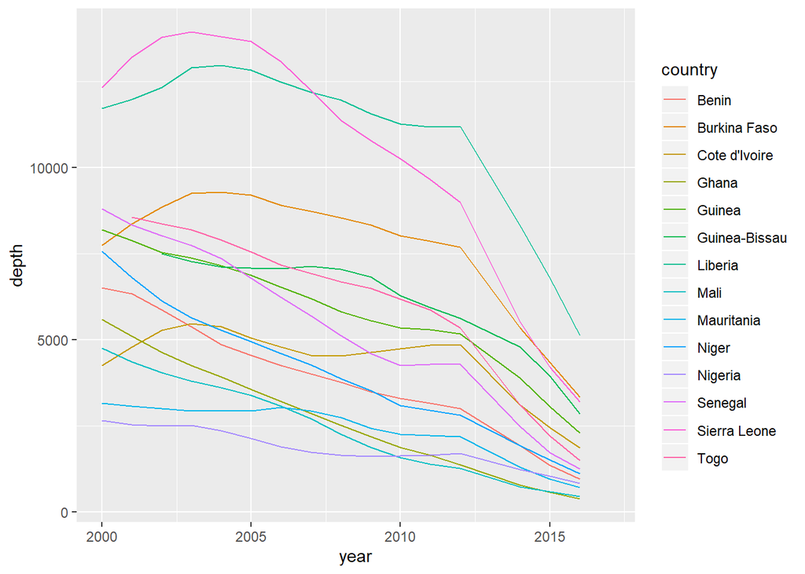

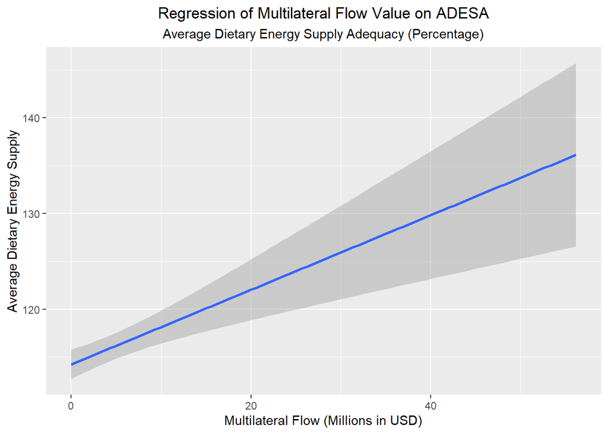

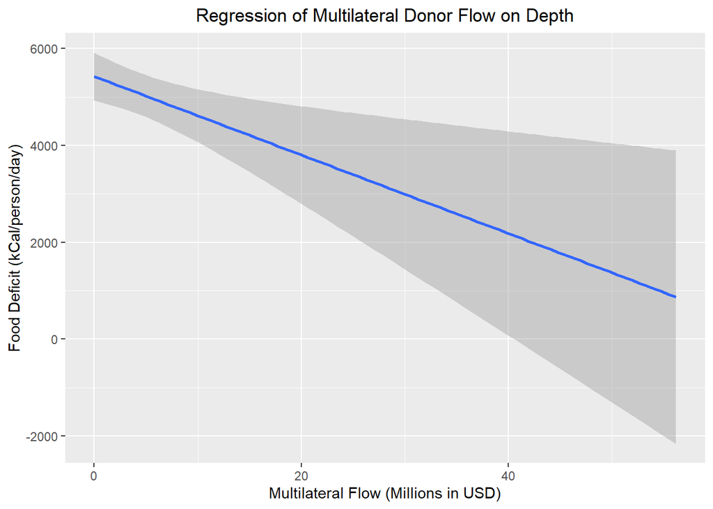

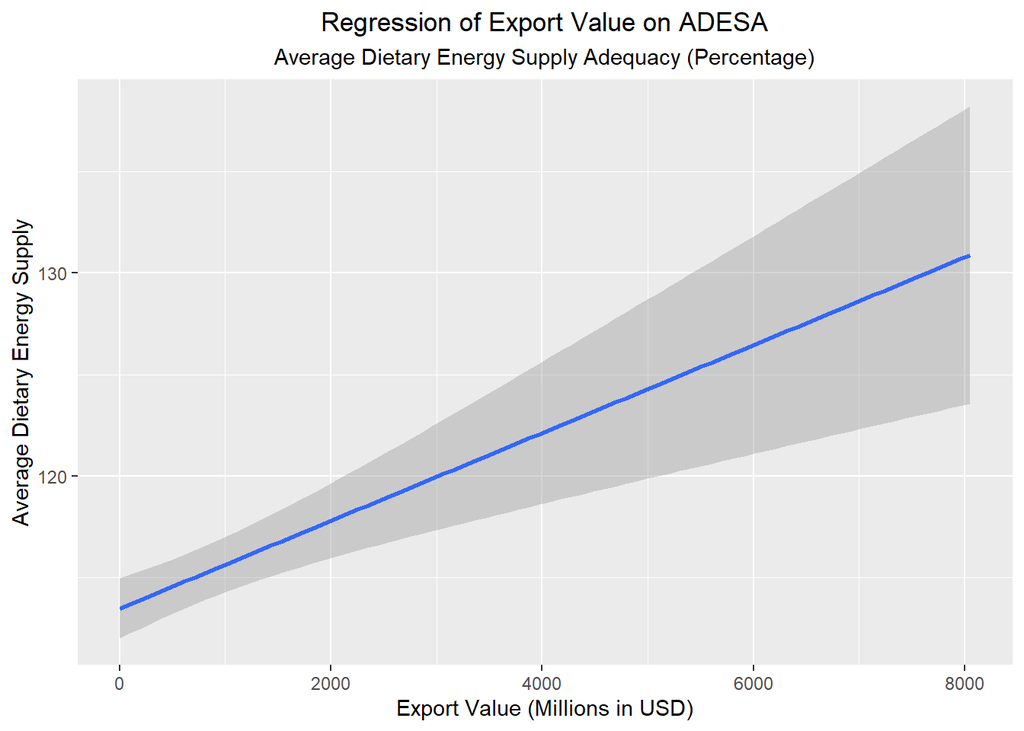

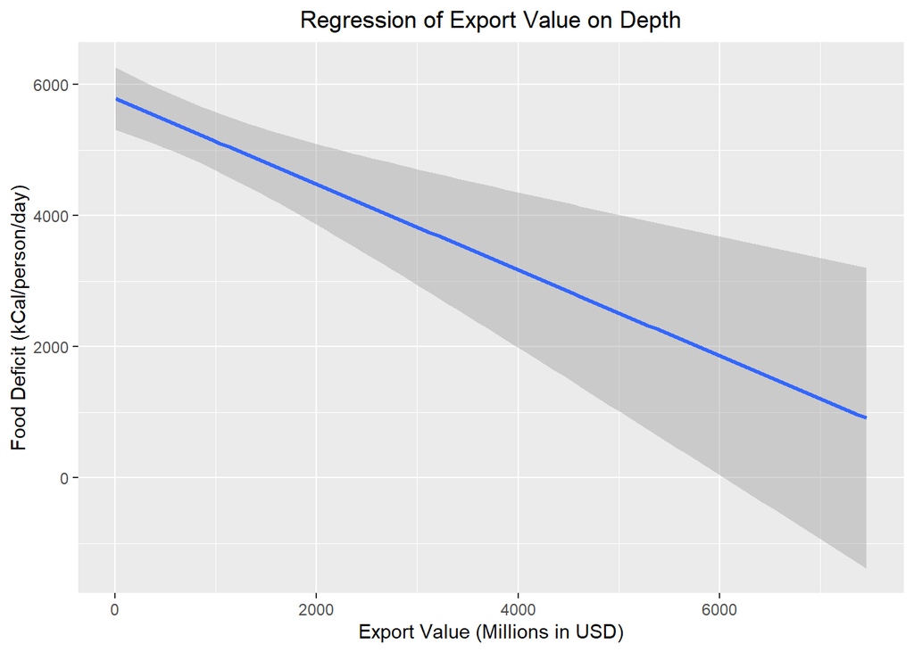

# Cluster Analysis

To more closely examine the trends uncovered by the linear regression model, we decided to complete a cluster analysis to examine how the different states have shifted in relation to each other. This analysis could potentially reveal additional information on how capital flows have impacted similar states. We focused on bilateral and multilateral development flows, as they contained the most complete data and clustering is ineffective with significant amounts of missing data. Due to the relatively small sample size, we utilized a hierarchical agglomerative method clustering process as it can identify nuance in small-n datasets which are harder to trace through k-means clustering.

This process examined the shifts in clusters at four time markers: 2000, 2005, 2010, and 2015. These time periods were selected as they contain most of the data, avoid incomplete data, and prevent an oversaturation of the dendrogram. The results are summarized in dendrograms created through `hclust`, with the closeness between clusters summarized through the `height` variable on the Y-axis.

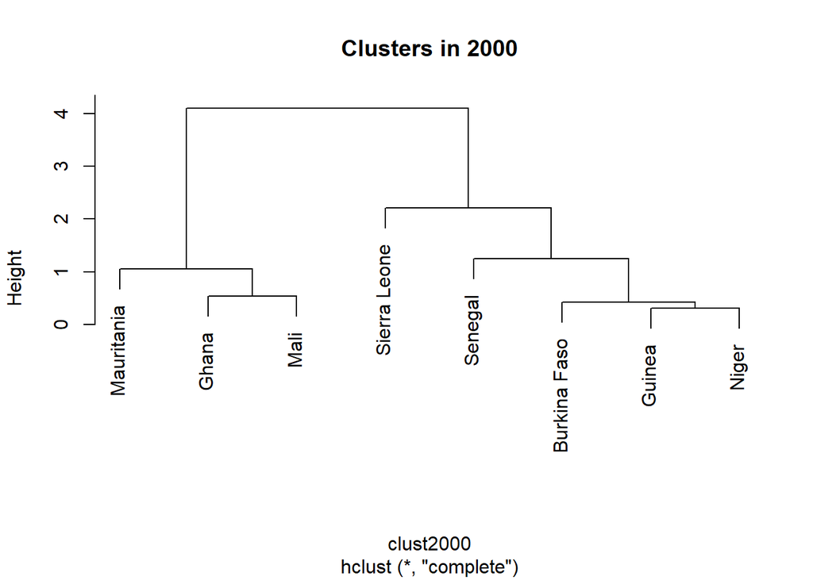

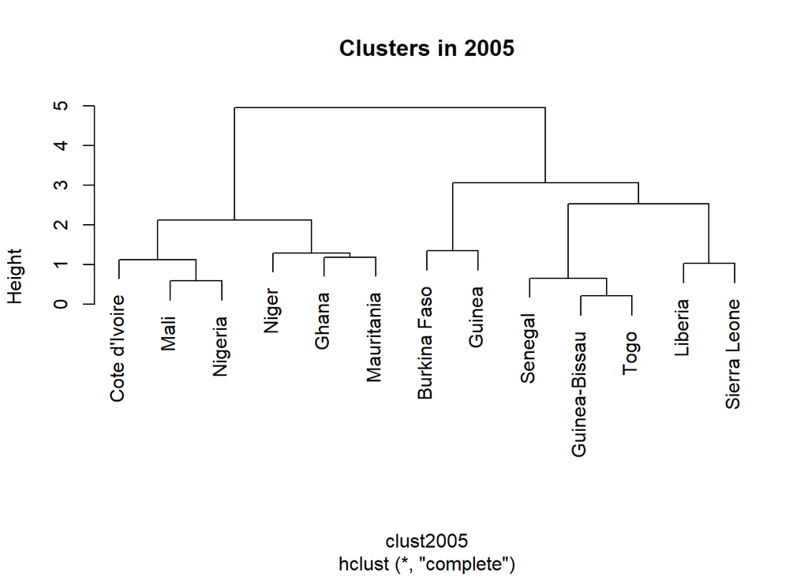

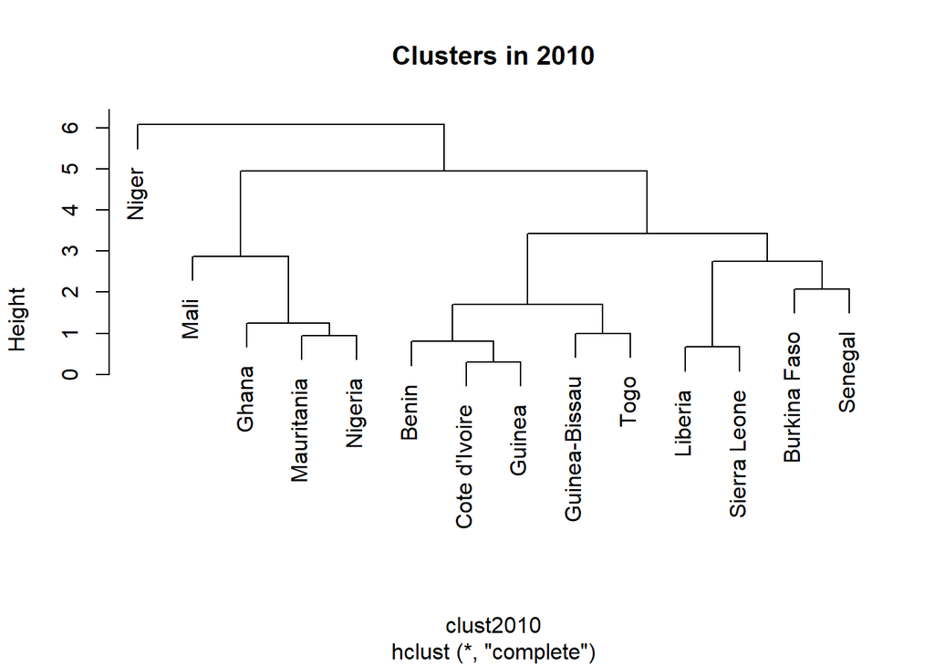

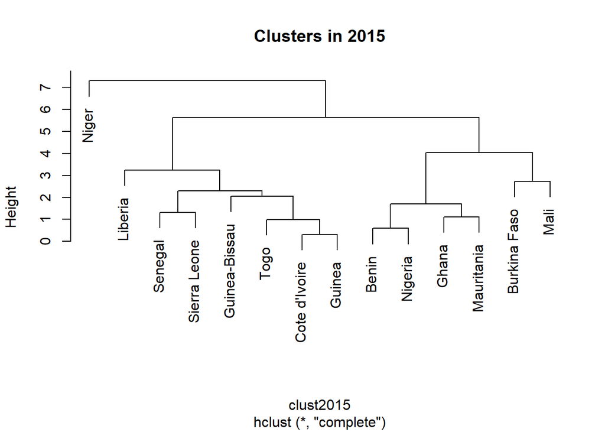

# Caveats and additional notes

Our study includes several caveats, which we would like to address in this section. These caveats are evaluated in terms of data collection, data cleaning, and analysis.

## Collection

This data was gathered by the Food and Agriculture Organization of the United Nations (FAO). While the FAO indicates that most of its data is from a third party which often has its own data integrity standards, our team does not know the exact data collection methods and decisions made in the moment. For this reason, we acknowledge that there may be unknown sources of collection bias. To help mitigate these effects, we reviewed the codebook for each data set.

Growth domestic product (GDP) is not included in this dataset. While GDP is a commonly used variable when examining country-level growth , we chose to focus on capital flows. Policymakers have several policy levers at their disposal which can impact capital flows, such as banking regulations or legislation. We included capital flows instead of GDP to focus on the relationship between policymakers and nutrition outcomes.

## Cleaning

To clean this dataset, we kept `country` and `country_code` as the unique identification variables for each observation. This decision relies on the assumption that country would be the. main variable by which we would need to use numerical identification as fallback.

The USD values for the Foreign Direct Investment (FDI) dataset were adjusted from 2010 USD values to 2016 USD values. This adjustment was made in light of the Development Aid (DevAid) dataset, which included 2016 USD values. We could have adjusted the DevAid values to 2010, but decided to use the most recent value of 2016 instead. This logic also considers that our dataset includes years from 2000 to 2017.

The Crops and Livestock Import and Export (Trade) datasets included import and export values in units of thousands, while the other four datasets of this study were in units of millions. To reconcile this difference, we divided the trade values `exp_value` and `imp_export` by 1,000 so that these values would be represented in millions.

## Analysis

Our analysis includes a linear regression and cluster analysis. While we did attempt to. execute a Bayesian regression at the beginning of the study, our final study does not include this analysis. We recognize that a Bayesian regression method may have been a more robust analysis method. However, due to our levels of statistical experience and background, we executed a multivariate linear regression. To continue to increase our knowledge in statistical methods, we focused on pushing our newly gained knowledge from the course via the cluster analysis.

The linear regression in our study excludes a flow type, `private`.The `private` observations were omitted from the regression due to their low n-size and minimal contribution to the exploratory Bayesian regression method mentioned above.

# Conclusion

The results of this analysis for global leaders and policy makers is clear, multilateral aid and agricultural exports increase food availability in West Africa. More specifically, a moderate investment in multilateral aid through organizations such as the World Bank, the World Food Program, or the United Nations Development Program significantly reduces the caloric deficit, helping those most in need. In turn, the promotion of agricultural exports increases the general availability of food in a country, supporting each facet of the population. Examining the results of the agglomerative clustering model can help creating multinational food security plans which build upon complementary experiences of states, while highlight those who may be diverging from the whole and require more nuanced programming.

Moving forward, additional research should focus on the nutritional status of individuals and whether gains in food availability are experienced equally across the population. It may be the case that populations are eating enough calories, but not consuming healthy numbers of micro and macro nutrients, or that gains in food availability are only experienced by specific segments of the population.